# Sampling Distributions Unveiled

# Sampling Distribution

#### What is a Sampling Distribution?

A sampling Distribution is a probability distribution found from repeated sampling from a specific population.

#### A look at the study

The sampling distribution that we will be looking at is for **Water Intake in Cups in a day** and **Max Bench Press**. We will discuss this distribution as well as single samples and how varying changes to our samples can affect the standard error.

## Water Intake and Max Bench Press

```r
n <- 100 #sample size
Xstart <- 8 #lower-bound for x-axis 8 cups of water
Xstop <- 18 #upper-bound for x-axis 18 cups of water

# average is 13 cups

beta_0 <- 10 #choice of true y-intercept
beta_1 <- 16.56 #choice of true slope
sigma <- 10 #choice of st. deviation of error terms
```

**The Law for Water Intake (C) and Max Bench Press**

$$\underbrace{Y_i}_{\text{Max Bench Press}} = \overbrace{\beta_0}^{10} +
\overbrace{\beta_1}^{16.56} \underbrace{X_i}_{\text{Water Intake (C)}} +
\epsilon_i \quad \text{where} \ \epsilon_i \sim N(0,
\overbrace{\sigma^2}^{\sigma=10})$$

### Explanation

What will be predicted is the **Max Bench Press** based on **Water Intake in Cups**. The **Y-Intercept**, based on the Law, is **10 pounds**, so if you drink no water for a day then your Max Bench Press will be 10 pounds. The **Slope**, based on the Law, is **16.56** so for every extra cup of water intake in a day the max bench press will go up by 16.56 pounds.

## Single Samples

```r
set.seed(42)
X <- rep(seq(Xstart,Xstop, length.out=5)) #Create X
Y <- beta_0 + beta_1*X + rnorm(5, 0, sigma) #Sample Y from true model
mylm <- lm(Y ~ X)
first <- data.frame(X,Y)
b <- coef(mylm)

set.seed(42)
X <- rep(seq(Xstart,Xstop, length.out=n/2), each=2) #Create X
Y <- beta_0 + beta_1*X + rnorm(n, 0, 100) #Sample Y from true model
mylm2 <- lm(Y ~ X)
second <- data.frame(X,Y)
b2 <- coef(mylm2)

set.seed(42)
X <- rep(seq(15,16, length.out=n/2), each=2) #Create X
Y <- beta_0 + beta_1*X + rnorm(n, 0, sigma) #Sample Y from true model
mylm3 <- lm(Y ~ X)
third <- data.frame(X,Y)
b3 <- coef(mylm3)

set.seed(42)
X <- rep(seq(Xstart, Xstop, length.out=n/2), each=2) #Create X
Y <- beta_0 + beta_1*X + rnorm(n, 0, sigma) #Sample Y from true model
mylm4 <- lm(Y ~ X)
fourth <- data.frame(X,Y)
b4 <- coef(mylm4)
```

### Normal Sample

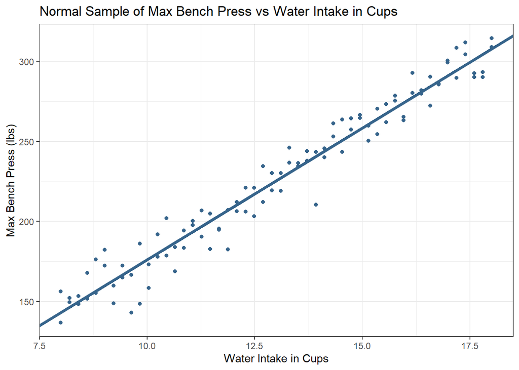

```r
ggplot(fourth, aes(X,Y)) +
  geom_point(color="steelblue4", pch=19) +
  geom_abline(slope=b4[2], intercept=b4[1], color="steelblue4", linewidth=1.5) +
  theme_bw() +
  labs(
    title="Normal Sample of Max Bench Press vs Water Intake in Cups",
    y="Max Bench Press (lbs)",
    x="Water Intake in Cups"
  )
```

```r
seY1 <- summary(mylm4)$coefficients[,2][[1]]
seX1 <- summary(mylm4)$coefficients[,2][[2]]
pander(paste0("Standard Error for Y-Intercept: ", round(seY1,3), "\n\n", "Standard Error for Slope: ", round(seX1,3)))
```

Standard Error for Y-Intercept: 4.736

Standard Error for Slope: 0.355

#### Explanation

This graph displays a “normal” sample or a sample that doesn’t have any drastic changes done to its properties based off of the Law or the norm in its population. This graph will be the benchmark for the **Low Sample Size**, **High Sigma**, and **Low Range of X’s** samples as we look at their Standard Errors for Y.

The standard errors in reference to our population mean that the Y-Intercept can vary by 4.74 pounds from the intercept at 11.24 pounds. This is all done in a t-distribution with 98 degrees of freedom.

The same applies to the standard error of the slope. The slope can vary by 0.36 pounds per cup of water, within the same t-distribution.

```r
pander(summary(mylm4))
```

|  | Estimate | Std. Error | t value | Pr(>\|t\|) |
| --- | --- | --- | --- | --- |
| **(Intercept)** | 11.24 | 4.736 | 2.373 | 0.01958 |
| **X** | 16.49 | 0.3553 | 46.41 | 1.63e-68 |

Fitting linear model: Y ~ X

| Observations | Residual Std. Error | $R^2$ | Adjusted $R^2$ |
| --- | --- | --- | --- |
| 100 | 10.46 | 0.9565 | 0.956 |

### Low Sample Size

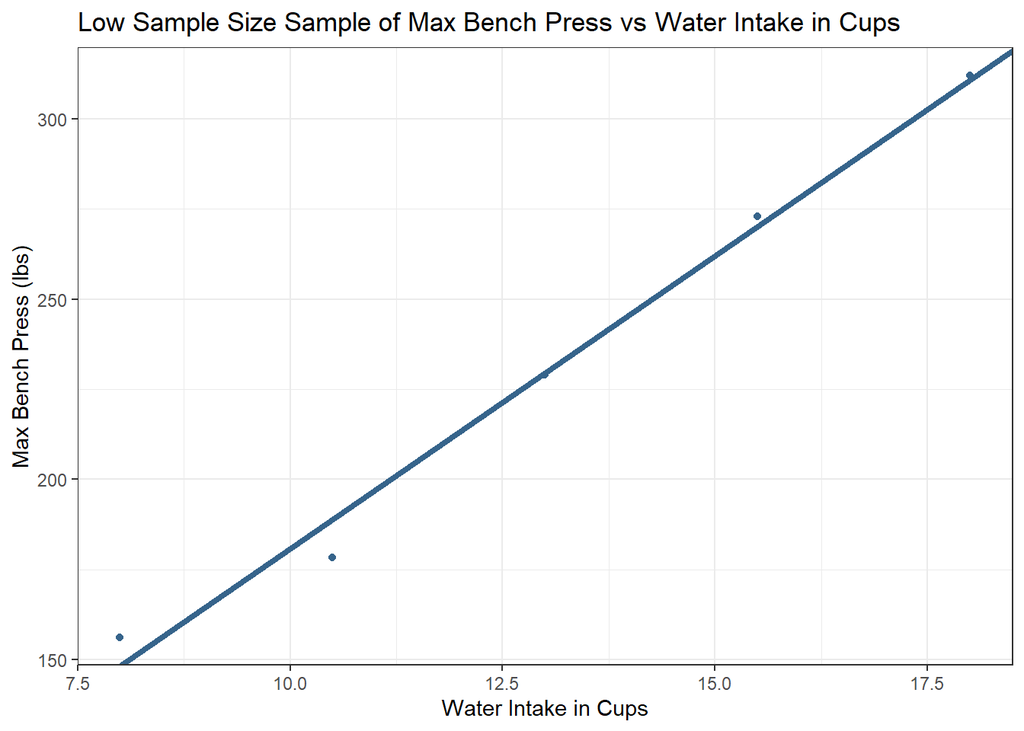

```r
ggplot(first, aes(X,Y)) +
  geom_point(color="steelblue4", pch=19) +
  geom_abline(slope=b[2], intercept=b[1], color="steelblue4", linewidth=1.5) +
  theme_bw() +
  labs(
    title="Low Sample Size Sample of Max Bench Press vs Water Intake in Cups",
    y="Max Bench Press (lbs)",
    x="Water Intake in Cups"
  )
```

```r
seY <- summary(mylm)$coefficients[,2][[1]]
seX <- summary(mylm)$coefficients[,2][[2]]
pander(paste0("Standard Error for Y-Intercept: ", round(seY,3), "\n\n", "Standard Error for Slope: ", round(seX,3)))
```

Standard Error for Y-Intercept: 13.441

Standard Error for Slope: 0.998

#### Explanation

Here we can see that the Standard Error for Y increased by around 3 times from having the sample size go from 100 to 5. The same is true for the Standard Error for X. The low sample size causes for a poorer fit between the points, there are less points to help explain variance in the model.

The same applies to the standard error of the slope. The slope can vary by 0.9977 pounds per cup of water, within the same t-distribution.

```r
pander(summary(mylm))
```

|  | Estimate | Std. Error | t value | Pr(>\|t\|) |
| --- | --- | --- | --- | --- |
| **(Intercept)** | 18.24 | 13.44 | 1.357 | 0.2679 |
| **X** | 16.27 | 0.9977 | 16.3 | 0.0005021 |

Fitting linear model: Y ~ X

| Observations | Residual Std. Error | $R^2$ | Adjusted $R^2$ |
| --- | --- | --- | --- |
| 5 | 7.887 | 0.9888 | 0.9851 |

### High Sigma

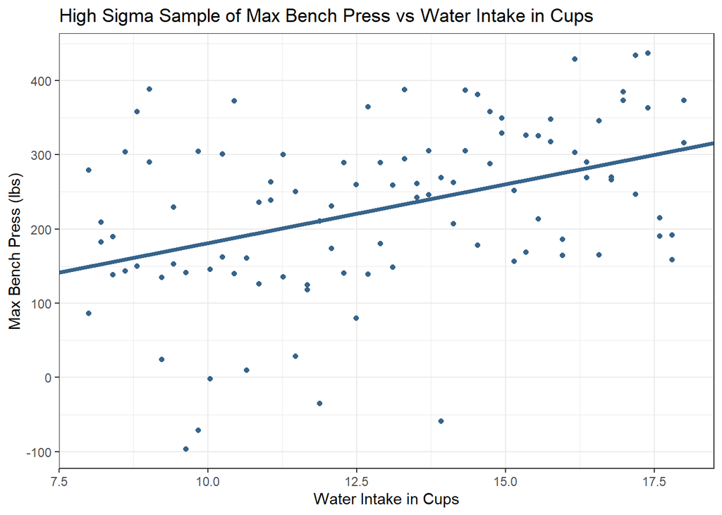

```r
ggplot(second, aes(X,Y)) +
  geom_point(color="steelblue4", pch=19) +
  geom_abline(slope=b2[2], intercept=b2[1], color="steelblue4", linewidth=1.5) +
  theme_bw() +
  labs(
    title="High Sigma Sample of Max Bench Press vs Water Intake in Cups",
    y="Max Bench Press (lbs)",
    x="Water Intake in Cups"
  )
```

```r
seY <- summary(mylm2)$coefficients[,2][[1]]
seX <- summary(mylm2)$coefficients[,2][[2]]
pander(paste0("Standard Error for Y-Intercept: ", round(seY,3), "\n\n", "Standard Error for Slope: ", round(seX,3)))
```

Standard Error for Y-Intercept: 47.362

Standard Error for Slope: 3.553

#### Explanation

The Standard Error for Y is drastically higher than the Low Sample Size Sample and that is because the standard error has a direct correlation with the standard error for the population. If at the population level the average distance between values and the mean is high then the distance will be even greater in a sample, even if it is the Standard error for the Y-Intercept and Slope. We can also see that some of the Y values go into the negatives and that the Y-Intercept, seen below, is 2 times the Law.

The standard errors in reference to our population mean that the Y-Intercept can vary by 47.36 pounds, which is significant since the Y-Intercept is at 22.41. This is all done in a t-distribution with 98 degrees of freedom.

The same applies to the standard error of the slope. The slope can vary by 3.55 pounds per cup of water, within the same t-distribution.

```r
pander(summary(mylm2))
```

|  | Estimate | Std. Error | t value | Pr(>\|t\|) |
| --- | --- | --- | --- | --- |
| **(Intercept)** | 22.41 | 47.36 | 0.4732 | 0.6371 |
| **X** | 15.86 | 3.553 | 4.462 | 2.167e-05 |

Fitting linear model: Y ~ X

| Observations | Residual Std. Error | $R^2$ | Adjusted $R^2$ |
| --- | --- | --- | --- |
| 100 | 104.6 | 0.1689 | 0.1604 |

### Low Range of X’s

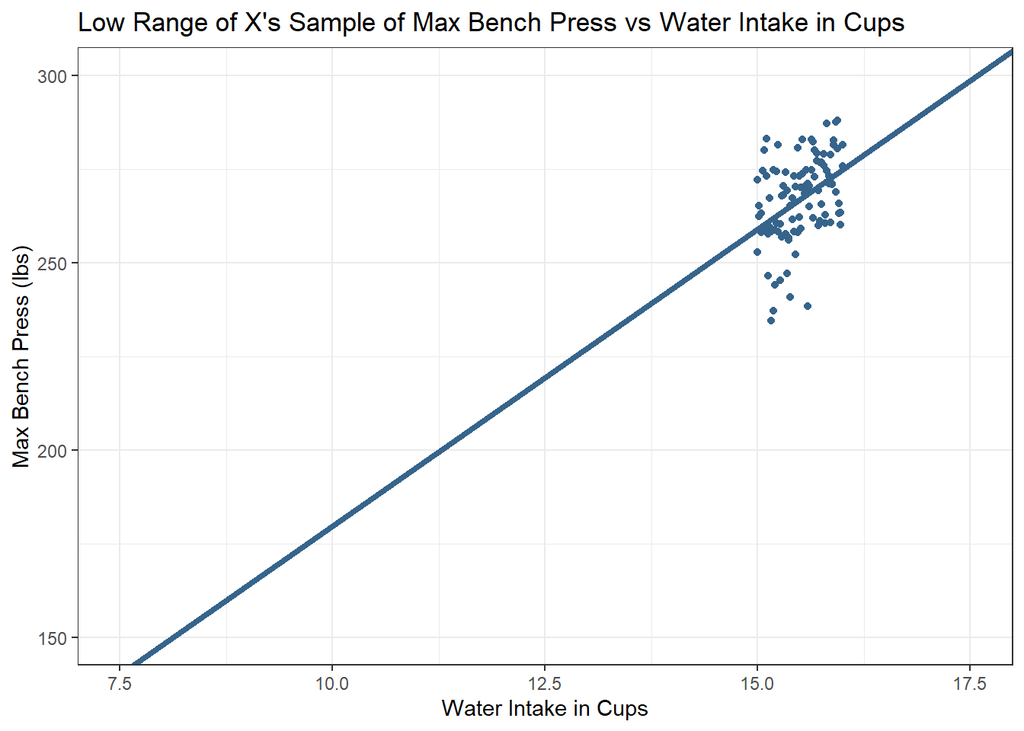

```r
ggplot(third, aes(X,Y)) +
  geom_point(color="steelblue4", pch=19) +
  geom_smooth(method="lm", se=FALSE, formula = y~x, color="steelblue4") +
  geom_abline(slope=b3[2], intercept=b3[1], color="steelblue4", linewidth=1.5) +
  theme_bw() +
  labs(
    title="Low Range of X's Sample of Max Bench Press vs Water Intake in Cups",
    y="Max Bench Press (lbs)",
    x="Water Intake in Cups"
  ) +
  coord_cartesian(xlim=c(7.5,17.5), ylim=c(150,300))
```

```r
seY <- summary(mylm3)$coefficients[,2][[1]]
seX <- summary(mylm3)$coefficients[,2][[2]]
pander(paste0("Standard Error for Y-Intercept: ", round(seY,3), "\n\n", "Standard Error for Slope: ", round(seX,3)))
```

Standard Error for Y-Intercept: 55.085

Standard Error for Slope: 3.553

#### Explanation

The points above are a lot closer to the line than with the High Sigma Sample; however, the Standard Error for the Y-Intercept is higher and the Standard error for the Slope is the same. This is because the points are so close together, as seen on the chart. This makes the Y-Intercept and Slope more susceptible to variation, because there are more ways that the line can fit through the points which can create a steeper or more gradual slope than is expected.

The standard errors in reference to our population mean that the Y-Intercept can vary by 55.08 pounds, which is significant when the Y-Intercept is 21.24 pounds. This is all done in a t-distribution with 98 degrees of freedom.

The same applies to the standard error of the slope. The slope can vary by 3.55 pounds per cup of water, within the same t-distribution.

```r
pander(summary(mylm3))
```

|  | Estimate | Std. Error | t value | Pr(>\|t\|) |
| --- | --- | --- | --- | --- |
| **(Intercept)** | 21.24 | 55.08 | 0.3857 | 0.7006 |
| **X** | 15.86 | 3.553 | 4.462 | 2.167e-05 |

Fitting linear model: Y ~ X

| Observations | Residual Std. Error | $R^2$ | Adjusted $R^2$ |
| --- | --- | --- | --- |
| 100 | 10.46 | 0.1689 | 0.1604 |

## Sample Distribution

The Sampling Distribution Below is made from 5000 samples. I set the X values to range from 8 to 18 cups, depending on how much the Y values are varied by the sigma the Y values will range from around 130 to 320 lbs. There are 100 X and Y values paired together to create a single sample and then those are put into a Linear Regression Model. Then the Slope and Y-Intercept along with the sigma are gathered. This occurs 5000 times and then we create a distribution of both Slope and Y-Intercept, as well as a graph of all the regression lines and the residual standard deviation that comes off of it.

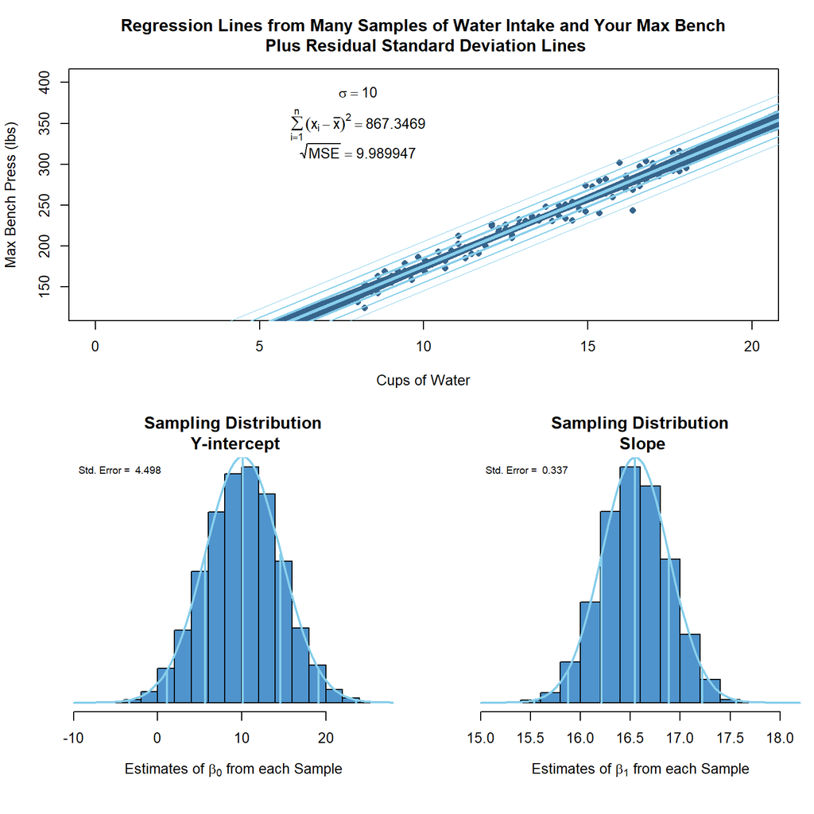

```r
X <- rep(seq(Xstart,Xstop, length.out=n/2), each=2) #Create X
N <- 5000 #number of times to pull a random sample
storage_b0 <- storage_b1 <- storage_rmse <- rep(NA, N)
for (i in 1:N){
  set.seed(i)
  Y <- beta_0 + beta_1*X + rnorm(n, 0, sigma) #Sample Y from true model
  mylm <- lm(Y ~ X)
  storage_b0[i] <- coef(mylm)[1]
  storage_b1[i] <- coef(mylm)[2]
  storage_rmse[i] <- summary(mylm)$sigma
}


layout(matrix(c(1,1,2,3), 2, 2, byrow = TRUE), widths=c(2,2), heights=c(3,3))

Ystart <- 120 #min(0,min(Y))
Ystop <- 405 #max(max(Y), 0)
Yrange <- Ystop - Ystart

plot(Y ~ X, xlim=c(min(0,Xstart-2), max(0,Xstop+2)),
     ylim=c(Ystart, Ystop), pch=16, col="steelblue4",
     main="Regression Lines from Many Samples of Water Intake and Your Max Bench\n Plus Residual Standard Deviation Lines", xlab="Cups of Water", ylab="Max Bench Press (lbs)")
text(Xstart, Ystop, bquote(sigma == .(sigma)), pos=1)
text(Xstart, Ystop-.1*Yrange, bquote(sum ((x[i]-bar(x))^2, i==1, n) == .(var(X)*(n-1))), pos=1)
text(Xstart, Ystop-.25*Yrange, bquote(sqrt(MSE) == .(mean(storage_rmse))), pos=1)


for (i in 1:N){
  abline(storage_b0[i], storage_b1[i], col="steelblue4")
}
abline(beta_0, beta_1, col="skyblue", lwd=3)
abline(beta_0+sigma, beta_1, col="skyblue", lwd=2)
abline(beta_0-sigma, beta_1, col="skyblue", lwd=2)
abline(beta_0+2*sigma, beta_1, col="skyblue", lwd=1)
abline(beta_0-2*sigma, beta_1, col="skyblue", lwd=1)
abline(beta_0+3*sigma, beta_1, col="skyblue", lwd=.5)
abline(beta_0-3*sigma, beta_1, col="skyblue", lwd=.5)

par(mai=c(1,.6,.5,.01))

  addnorm <- function(m,s, col="firebrick"){
    curve(dnorm(x, m, s), add=TRUE, col=col, lwd=2)
    lines(c(m,m), c(0, dnorm(m,m,s)), lwd=2, col=col)
    lines(rep(m-s,2), c(0, dnorm(m-s, m, s)), lwd=2, col=col)
    lines(rep(m-2*s,2), c(0, dnorm(m-2*s, m, s)), lwd=2, col=col)
    lines(rep(m-3*s,2), c(0, dnorm(m-3*s, m, s)), lwd=2, col=col)
    lines(rep(m+s,2), c(0, dnorm(m+s, m, s)), lwd=2, col=col)
    lines(rep(m+2*s,2), c(0, dnorm(m+2*s, m, s)), lwd=2, col=col)
    lines(rep(m+3*s,2), c(0, dnorm(m+3*s, m, s)), lwd=2, col=col)
    legend("topleft", legend=paste("Std. Error = ", round(s,3)), cex=0.7, bty="n")
  }

  h0 <- hist(storage_b0,
             col="steelblue3",
             main="Sampling Distribution\n Y-intercept",
             xlab=expression(paste("Estimates of ", beta[0], " from each Sample")),
             freq=FALSE, yaxt='n', ylab="")
  m0 <- mean(storage_b0)
  s0 <- sd(storage_b0)
  addnorm(m0,s0, col="skyblue")

  h1 <- hist(storage_b1,
             col="steelblue3",
             main="Sampling Distribution\n Slope",
             xlab=expression(paste("Estimates of ", beta[1], " from each Sample")),
             freq=FALSE, yaxt='n', ylab="")
  m1 <- mean(storage_b1)
  s1 <- sd(storage_b1)
  addnorm(m1,s1, col="skyblue")
```

#### Explanation

The mean for each of these distributions represents the Slope and Y-Intercept respectively. While the Std. Error is the Standard Error, this is essentially the standard deviation for the distribution. For each of the light lines that goes one from the mean, or middle line, the values are one standard error further away from the mean and each distribution shows 3 standard errors out. So around 99% of the data are within the distributions.

The mean for the Y-Intercept seems to be exactly at 10 or close to it, which is the Y-Intercept according to the Law made earlier.

## Standard Error Calculations

$$s^2_{b_1} = MSE
\Bigg[\frac{1}{n}+\frac{\bar{X}^2}{\sum^n_{i=1}(X_i-\bar{X})^2}\Bigg]$$

This states that the standard error for the Y-Intercept is the MSE times 1 over the sample size plus the mean of the X values squared divided by the sum of all observed X values minus the mean of the X values squared.

$$s^2_{b_1} = \frac{MSE}{\sum^n_{i=1}(X_i-\bar{X})^2}$$

This states that the standard error for the Slope is the MSE over the sum of all observed X values minus the mean of the X values squared.

# P-Values

## Hypotheses

$$H_0 : \beta_0 = 10\\
H_a : \beta_0 \neq 10\\
~\\
H_0 : \beta_1 = 16.56\\
H_a : \beta_1 \neq 16.56$$

### Explanation

The first hypotheses state that the null hypothesis for the Y-Intercept is that it equals 10 lbs and the alternative is that it is not equal to 10 lbs.

The second hypotheses state that the null hypothesis for the Slope is that it equals 16.56 pounds per cup of water and the alternative is that the Slope is not equal to 16.56 pounds per cup of water.

## How to Get a P-Value

#### What is a P-Value

A P-Value is the measure of values more extreme than the sample you have obtained.

#### Explanation

To obtain this we need to figure out how to get a measure of what is above or below a value. This is done through percentiles and quantiles. However, since we can’t use a normal or Z distribution for this since it isn’t a measure from the population we need to use a t-distribution. A t-distribution varies based on degrees of freedom, in this case is n-2 since we are predicting two values (Slope and Intercept).

We luckily don’t have to calculate any of this by hand, we get how many standard errors away from the predicted Slope and Y-Intercept and then plug that into pt along with the degrees of freedom. This will give us the percentile below our t-value. So, we need to make sure that it is negative to ensure that we get the value more extreme than ours, then we double it to get both tails since our Hypotheses are two tailed.

$$\text{2 * pt( -abs(t), df or n-2 )}$$

## Getting the T-Value

$$\frac{(b_0 - \beta_0)}{\text{s}_{b_0} \text{ (Standard Error)}}\\
~\\
\frac{(b_1 - \beta_1)}{\text{s}_{b_1} \text{ (Standard Error)}}$$

For most instances Beta 0 is left as 0; however, in some instance that doesn’t make since. Especially, if we already have a figure in mind that we want to test against. In this case we know what the population slope and y-intercept are so I will show how to get the p-value for both instances of 0 and the population values.

So we subtract the predicted value from the value assumed by the null hypothesis and then divide it by their respective standard error.

## Getting our P-Value

```r
t <- (b4[1] - beta_0)/seY1
p_val_0 <- 2 * pt(-abs(t), n-2)
t0 <- (b4[1] - 0)/seY1
p_val_01 <- 2 * pt(-abs(t0), n-2)

t1 <- (b4[2] - beta_1)/seX1
p_val_1 <- 2 * pt(-abs(t1), n-2)
t11 <- (b4[2] - 0)/seX1
p_val_11 <- 2 * pt(-abs(t11), n-2)

pander(paste0("P-Value for Beta 0 = 11 : ", round(p_val_0,3), "\n\n",
              "P-Value for Beta 0 = 0 : ", round(p_val_01,3), "\n\n\n\n",
              "P-Value for Beta 1 = 16.56 : ", round(p_val_1,3), "\n\n",
              "P-Value for Beta 1 = 0 : ", round(p_val_11,3)))
```

[output not shown]

P-Value for Beta 0 = 0 : 0.02

P-Value for Beta 1 = 16.56 : 0.843

P-Value for Beta 1 = 0 : 0

#### Checking against the lm Summary:

```r
pander(summary(mylm4))
```

|  | Estimate | Std. Error | t value | Pr(>\|t\|) |
| --- | --- | --- | --- | --- |
| **(Intercept)** | 11.24 | 4.736 | 2.373 | 0.01958 |
| **X** | 16.49 | 0.3553 | 46.41 | 1.63e-68 |

Fitting linear model: Y ~ X

| Observations | Residual Std. Error | $R^2$ | Adjusted $R^2$ |
| --- | --- | --- | --- |
| 100 | 10.46 | 0.9565 | 0.956 |

#### Explanation

The p-values for each Slope and Y-Intercept set to 0 are significant, which means that they are not equal to 0.

However, the p-values for each Slope and Y-Intercept that are set to the population parameters are insignificant, which means that we haven’t disproven that they are equal to the population parameters.

The p-values calculated in the lm summary are the hypotheses that are checked against 0, and if we look above we can see that they match with the values that we calculated from checking our predictions to 0.

# Confidence Intervals

## The Confidence Interval Captures the True Parameter “95% of the time?”

The Confidence Interval only captures the true parameter 95%, or whatever confidence level you are using, because it is using the sample Y-Intercept or Slope. So if the sample statistic is far enough away from the population parameter then the true parameter could be outside of the interval. It could also be because of a Type II Error, which is failing to reject the null when it is actually false. This could lead to a false assumption that the sample statistic is within 2 or 3 standard errors of the population parameter.

## How to Get a Confidence Interval

#### What is a Confidence Interval?

The Confidence Interval is an interval in which there is a given probability that the population parameter will be within for a proportion of times.

#### Explanation

To get a confidence interval we first decide what confidence level we want to use. We will be using a 95% confidence level later on so that is what we will infer to be using now, to get this from the qt we have to subtract it from 1 and then divide the difference by 2 and then add it to the initial confidence level. In this case we would use a .975 percentile.

To get the measurement of the critical t-value we will use the qt function which will get the quantile from a percentile and the degrees of freedom for a given t-distribution. After that you multiply the critical t-value by the given standard error.

Lastly you subtract and add from the Slope or Y-Intercept, depending on what you are getting the confidence interval for.

$$\text{b}_0 \pm \text{qt(percentile, df or n-2) * s}_{b_0}\\
~\\
\text{b}_1 \pm \text{qt(percentile, df or n-2) * s}_{b_1}$$

## Getting our Confidence Intervals

```r
conf_0 <- b4[1] + c(-1,1) * (qt(.975, n-2) * seY1)

conf_1 <- b4[2] + c(-1,1) * (qt(.975, n-2) * seX1)

pander(paste0("Confidence Interval for Y-Intercept : (", round(conf_0[1],3), ", ", round(conf_0[2],3), ")\n\n",
              "Confidence Interval for Slope : (", round(conf_1[1],3), ", ", round(conf_1[2],3), ")"))
```

Confidence Interval for Y-Intercept : (1.842, 20.64)

Confidence Interval for Slope : (15.784, 17.195)

#### Checking our calculations to the confint() function:

```r
conf_0 <- confint(mylm4)


pander(conf_0)
```

|  | 2.5 % | 97.5 % |
| --- | --- | --- |
| **(Intercept)** | 1.842 | 20.64 |
| **X** | 15.78 | 17.19 |

#### Explanation

Here we can see that we were able to replicate the results from the confint() function for both the Y-Intercept and Slope.